# **Module 1: Programming Fundamentals for Machine Learning**

### **Instructor**: Dr. Hum Nath Bhandari, Department of Mathematics and Physics, RWU

### **Course**: MATH355/COMSC 415-Machine Learning

### **Lab 1**: Programming Fundamentals for Machine Learning

### **Your Name:** Penn Potter

## **Instructions:**

- Download this file from Bridges.
- Save the file into your local computer inside **Machine Learning** folder.
- Open the file from Jupyter and solve the following questions using python functionality. You can use Jupyter notebook in your local machine.
- Once you are done, upload your final product on Bridges. You should upload both original notebook and corresponding html document.
- I recommend to save a copy in your google drive.
- You can complete the quiz by using Google Colab if you prefer this option.

## **Academic Integrity Guidelines**

- Sharing notebooks/files with friends, on social media, chat or in any platform is considered as 'Academic Dishonesty' as stated in the Syllabus.
- Your work should be original. You can discuss with friends, use available resources, and get ideas but write your own solution for the given question. If it is copied from friends/any online resoureces, you will receive 0 and its a last warning. If it happens second time, it will be reported to the university.
- **Citation**: If you use the code of this class for any purpose, outside the class assignments, you are expected to give the credits to the class and the corresponding instructor. Any form of digital publication of the class material without permission of the instructor is strictly prohibited.

### Refereces for Programming Fundamentals

- **Notebook 1(System Installations)**: Getting ready with the necessary systems and packages.
- **Notebook 2(Basic Python Tutorial)**: Creating variables in Python, basic python data structures , random numbers generators, conditional statements, loop operations in python, etc
- **Notebook 3(Numpy Tutorial)**: creating vectors, matrices, and multi-dimensional arrays, indexing and slicing arrays, reshaping and resizing arrays, vectorized implementation of mathematical operations, matrix and vector operations in arrays, etc.
- **Notebook 4(Pandas Tutorial)**: Introducing pandas Series and Dataframe, basic operations with Pandas.
- **Notebook 5(Basic Visualization with Matplotlib)**: This includes functionality for plotting and visualization. There are a number of high quality visualization libraries in python such as Matplotlib and Seaborn. The most popular general-purpose visualization library is Matplotlib, which mainly focuses on generating static publication-quality 2D and 3D graphs.
- **Notebook 6(Advanced Visualization with Seaborn)**: This includes additional python functionality for plotting and visualization. We focus on plotting and visualization using real-world data. To accomplish our goal we use important Seaborn functionality for static visualization.

## Part I : Understanding Scope of Data Science and Machine Learning

### Suggested Reading(Available free on Bridges):

- **Hands-On Machine Learning with Scikit-Learn, Keras, and TensorFlow by Aurélien Géron**

### **Question 1:**

- What is data science? (about 100 words)
- Which field of data science you are interested in and why?
- Write a possible project/application of data science in the field you are interested in( about 100 words)
1. Data science is about interpreting data and manipulating it to show patterns, interpret behaviors, or other gather some other metric from it. It involves the use of numerous tools, and involves many different industries. There is also a lot of analysis involved, including statistics and programming, to make sense of large amounts of information. Data science helps companies and groups answer questions, predict outcomes, and improve decision making.
2. I am interested in the AI/ML part of data science, and how we can use that to make better decisions, and accelerate areas of research and production.
3. One of the projects that I am interested in is creating a camera system for police or other law enforncement vechiles, that can recognize dangerous driving patters that the officers might not notice, and record the license plate of the vehicle that commited the infraction. I belive that this could be a cool use of AI and could actually be used in the real world.

### **Question 2:**

Watch the Youtube video: https://www.youtube.com/watch?v=X3paOmcrTjQ

- List the major steps follwed in Data Science projects. Explain each point in two or three lines.
- What are the applications discussed in the video?
- The steps are:
  1. Understanding the buisness problem, where you understand the specific problem that data science needs to solve.
  2. Data acquisition, where you collect the raw data for later use in the project.
  3. Data preperation is where you clean the data, and get it ready for analysis and to display by removing blank data or outliers. 4.Exploratory Data Anaysis is when you take time to understand the data and what it is telling you through visualizing it or finding statisitics about it.
  4. Data Modeling is where you take ML algorithms and models and apply it to the data, to get insights about it.
  5. Visualization and Communication is where you take what you have found and display it in a readable format for people to understand.
  6. Deploy and Maintenance is where you take the model that you have made and put it into the real world, and monitor how it performs.
- Applications discussed
  1. Genetics
  2. Logitistics like DHL
  3. Employee retention
  4. Flight delay

### **Question 3**:

Watch the Video and answer the following questions: https://www.youtube.com/watch?v=HgBpFaATdoA

- What is the place of machine learning in a broader discussion of Artificial Intelligence?
- Can you provide some popular AI products which are being used by different companies?
- What are the major steps of machine learning pipline?
- Discuss different types of machine learning techniques?(100 words)
- What are the necessary machine learnng pre-requisite skills?
- What is data wrangling?
- List and briefly discuss real-word applications of Machine Learning?
- AI is the broad topic of intelligent computers, and machine learning is algorithms that gives ai the ability to learn and adapt
- Amazon Echo, IBM Deep Blue, and Number Plate Recognition are all things that use AI
- The major steps are cleaning the data, traning the model off the data, adding new data to the model, using the model to predict and then checking the outcome agains the data, and retraining as needed.
- Different types of learning:
  1. Supervised learning is when you use a certian amount of labeled data for training. This allows the model to take the data it knows, and when presented with new data, is able to match it to the data it already knows and interpret what this new data is.
  2. Unsupervised learning is when you take a bunch of unlabled data and let the model figure it out. It takes the unlabled data and correlates them into groups of things it finds simaler. It might not know what they are but it can gather that they look alike.
- You need to know some programming, some knowledge of statistics, math like linear algebra and calculus, and some experience cleaning data.
- Data wranging is where you clean and prepare data to feed into a ML model. It allows the model to have the best performance and outcome, and remove the bad data.
- Object detection and Plate Reading are good examples of real world applications, and it is tedious and expensive to have humans do it all the time, but if you can have an alogrithm do it then it makes many more projects viable.

## Part II: Understanding Basic Python (Reference: Notebook 2)

### Learning Objectives

- Printing in basic python.
- Wroking with loop such as **for loop** and **while loop**.
- Working with random numbers generators.
- Implementing **list** and **dictionary** objects.
- Getting user inputs.
- Creating and applying user defined functions.

### **Question 4**:

Perform the follwing tasks.

- Import a python library which helps to create random numbers
- Create a variable with the name **my_list** starting from empty list.
- Use either **for** or **while** loop to fill 10 random integers between 1 to 20 in the **my_list** using **append()** function.
- Print the first 5 random integers from the list.

```python
# import numpy for random number generation
import numpy as np

my_list = []

#loop
for i in range (10):
    #use numpy to generate random number
    #append to list
    my_list.append(np.random.randint(1,20))

#print fist 5 elements of list using array slicing https://www.w3schools.com/python/numpy/numpy_array_slicing.asp
print(my_list[:5])
```

```
[1, 1, 3, 9, 15]
```

### **Question 5**:

Perform the following tasks.

- Create a list, called, **students**, consisting name of five students (only first name will be fine). These names can be your friend's names or any hypothetical names.
- Create another list, called, **grades**, consisting some hypothetical percentage grade scores ranging from 0 to 100.
- Now, create a dictionary, called **grades_sheet**, by combining two lists (**students** and **grades**) using **zip()** function. Display the dictionary.
- Display/print **keys** and **values** of **grades_sheet** dictionary.
- Extract one of the keys from your **grade_sheet** dictionary and modify it by assigning different value.

```python
import numpy as np

#create the students list
students = ['Alice', 'Bob', 'Charlie', 'David', 'Eva']

#create the list called grades and randomly populate
grades = []
for i in range(len(students)):
    grades.append(np.random.randint(0,100))

#create the dictionary
grades_sheet = dict(zip(students, grades))

#display the dictionary
print("Grades Sheet:")
print(grades_sheet)

#print keys
print("Keys:")
print(grades_sheet.keys())

#print values
print("Values:")
print(grades_sheet.values())

#change value in dictionary
print("Alices original grade:")
print(grades_sheet['Alice'])
print("Alices new grade:")
grades_sheet['Alice'] = 95
print(grades_sheet['Alice'])
```

```
Grades Sheet:
{'Alice': 54, 'Bob': 69, 'Charlie': 5, 'David': 97, 'Eva': 31}
Keys:
dict_keys(['Alice', 'Bob', 'Charlie', 'David', 'Eva'])
Values:
dict_values([54, 69, 5, 97, 31])
Alices original grade:
54
Alices new grade:
95
```

### **Question 6**:

Write a simple python function, called **simple_interest_calculator()** which performs the following tasks.

- Takes principal (P) in USD, interest rate (R) in percentage, and time (T) in years from users.
- Computes simple interest (I) by using the following formula

  $$I=\frac{PRT}{100}$$
- Produces simple interest as an output. Use print() function while producing results.

Now, run the program for the following inputs.

1. P = $5000, R = 4.8%, T = 5 years
2. P = $10000, R = 3%, T = 4 years

```python
def simple_interest_calculator(p,r,t):
    print("Simple Interest for Principal:", p, "Rate:", r, "Time:", t,":")
    # do the math and print it
    print((p*r*t)/100)

#call the function with question values
#simple_interest_calculator(5000,.48,5)
#simple_interest_calculator(10000,.3,4)

#alternatively get input
def simple_interest_calculator_input():
    #get user input
    p = float(input("Enter the principal amount: "))
    r = float(input("Enter the rate of interest using decimal format (eg 1 = 100%): "))
    t = float(input("Enter the time in years: "))
    # do the math and print it
    print((p*r*t)/100)

#call the function with user input
simple_interest_calculator_input()
```

```
6000.0
```

## Part III: Understanding Numpy ( Reference: Notebook 3)

### Learning Outcomes

- Basic NumPy functionaliy
- Creating arrays
- Indexing, slicing, and reshaping arrays
- Aggregation functions
- Random number generators
- Vectorized implementation of functions

### **Question 7**:

Import NumPy library and create a two dimensioanl array of some numbers using **array()** method. Shape of your array must be of (3,4) and data type must be **float64**. Use NumPy attributes (metadata) to display the following.

- What is the dimension of the array?
- What is the shape of the array?
- What is the size of the array?
- What type of data is there in the array?

```python
import numpy as np

#create the 3,4 array
array = np.random.randint(1,10,size=(3,4))
#array as float as we cannot cast it w/ dtype when creating with integers randomly
array = array.astype(float)
print(array)

#get dimensions and shape of array
print("Array dimensions:", array.ndim)
print("Array shape:", array.shape)
print("Array size:", array.size)
print("Array data type:", array.dtype)
```

```
[[8. 3. 4. 5.]
 [4. 5. 5. 6.]
 [9. 1. 3. 2.]]
Array dimensions: 2
Array shape: (3, 4)
Array size: 12
Array data type: float64
```

### **Question 8**:

Create an array, called **A** with 50 equi-spaced numbers between 0 to 100 inclusive. And answer the following questions.

- Select and display first 20 elements from A
- Select and display last 10 elements from A
- Select and display 5 elements starting from index 30
- Select and display the elements which are greater than 50
- Reshape A array in (10, 5) shape and save the data as array B.
- Check the shape of the new array B.
- Transpose B and save this array as C and check shape of this transpose array.
- Collapse C in to one dimensional array and save it as D and then check the dimension.
- Merge array D with itself using vertical stacking and save the data as E. Display the new array E. What is the shape of E?
- Convert D as column vector, merge this array with itself using horizontal stacking and save this data as F. Also display F and check the shape of F.
- Select first 10 rows from F and save this data as G. Make sure G must be an independent copy (i.e changing G should not change F). Apply the following aggregate functions.
  - Find sum of all elements of G
  - Average of all elements of G
  - Sum of each column( i.e column-wise sums, add all rows of each column). **Hint** use axis = 0
  - Sum of each row (i.e row-wise sums)
  - Average of each row

```python
import numpy as np
#init array
a = []
#for loop to create 50 equispaced numbers between 0 and 100
a = np.linspace(0,100,50)
#display the first 20 elements of a
print("First 20 elements of a:")
print(a[:20])
#display the last 10 elements of a
print("Last 10 elements of a:")
print(a[-10:])
#display 5 elements starting from index 30
print("5 elements from index 30:")
print(a[30:35])
#display elements greater than 50
print("Elements greater than 50:")
print(a[a>50])
#reshape a into b
b = np.array(a).reshape(10,5)

#print shape of b
print("Shape of b:", b.shape)

#transpose b into c
c = np.transpose(b)

#collapse c into one dimensional array d
d = c.flatten()

print("Dimension of d:", d.ndim)

#merge array d with itself into e
e = np.concatenate((d,d))
print("Array e:")
print(e)
print("Shape of e:", e.shape)

#get d column vector merge with itself horizontally and name f
f = np.column_stack((d,d))
print("Array f:")
print(f)
print("Shape of f:", f.shape)

#first 10 rows of f into g independently
#https://www.geeksforgeeks.org/python/numpy-copy-and-view/
g = f[:10,:].copy()

#sum of g
print("Sum of g:", np.sum(g))
#average of g
print("Average of g:", np.mean(g))
#sum of each column of g
print("Sum of each column of g:", np.sum(g, axis=0))
#sum of each row of g
print("Sum of each row of g:", np.sum(g, axis=1))
#average of g rows
print("Average of each row of g:", np.mean(g, axis=1))
```

```
First 20 elements of a:
[ 0.          2.04081633  4.08163265  6.12244898  8.16326531 10.20408163
 12.24489796 14.28571429 16.32653061 18.36734694 20.40816327 22.44897959
 24.48979592 26.53061224 28.57142857 30.6122449  32.65306122 34.69387755
 36.73469388 38.7755102 ]
Last 10 elements of a:
[ 81.63265306  83.67346939  85.71428571  87.75510204  89.79591837
  91.83673469  93.87755102  95.91836735  97.95918367 100.        ]
5 elements from index 30:
[61.2244898  63.26530612 65.30612245 67.34693878 69.3877551 ]
Elements greater than 50:
[ 51.02040816  53.06122449  55.10204082  57.14285714  59.18367347
  61.2244898   63.26530612  65.30612245  67.34693878  69.3877551
  71.42857143  73.46938776  75.51020408  77.55102041  79.59183673
  81.63265306  83.67346939  85.71428571  87.75510204  89.79591837
  91.83673469  93.87755102  95.91836735  97.95918367 100.        ]
Shape of b: (10, 5)
Dimension of d: 1
Array e:
[  0.          10.20408163  20.40816327  30.6122449   40.81632653
  51.02040816  61.2244898   71.42857143  81.63265306  91.83673469
   2.04081633  12.24489796  22.44897959  32.65306122  42.85714286
  53.06122449  63.26530612  73.46938776  83.67346939  93.87755102
   4.08163265  14.28571429  24.48979592  34.69387755  44.89795918
  55.10204082  65.30612245  75.51020408  85.71428571  95.91836735
   6.12244898  16.32653061  26.53061224  36.73469388  46.93877551
  57.14285714  67.34693878  77.55102041  87.75510204  97.95918367
   8.16326531  18.36734694  28.57142857  38.7755102   48.97959184
  59.18367347  69.3877551   79.59183673  89.79591837 100.
   0.          10.20408163  20.40816327  30.6122449   40.81632653
  51.02040816  61.2244898   71.42857143  81.63265306  91.83673469
   2.04081633  12.24489796  22.44897959  32.65306122  42.85714286
  53.06122449  63.26530612  73.46938776  83.67346939  93.87755102
   4.08163265  14.28571429  24.48979592  34.69387755  44.89795918
  55.10204082  65.30612245  75.51020408  85.71428571  95.91836735
   6.12244898  16.32653061  26.53061224  36.73469388  46.93877551
  57.14285714  67.34693878  77.55102041  87.75510204  97.95918367
   8.16326531  18.36734694  28.57142857  38.7755102   48.97959184
  59.18367347  69.3877551   79.59183673  89.79591837 100.        ]
Shape of e: (100,)
```

[output cut: 44 more lines]

```
 [ 38.7755102   38.7755102 ]
 [ 48.97959184  48.97959184]
 [ 59.18367347  59.18367347]
 [ 69.3877551   69.3877551 ]
 [ 79.59183673  79.59183673]
 [ 89.79591837  89.79591837]
 [100.         100.        ]]
Shape of f: (50, 2)
Sum of g: 918.3673469387755
Average of g: 45.91836734693878
Sum of each column of g: [459.18367347 459.18367347]
Sum of each row of g: [  0.          20.40816327  40.81632653  61.2244898   81.63265306
 102.04081633 122.44897959 142.85714286 163.26530612 183.67346939]
Average of each row of g: [ 0.         10.20408163 20.40816327 30.6122449  40.81632653 51.02040816
 61.2244898  71.42857143 81.63265306 91.83673469]
```

### **Question 9**:

Create two one-dimensional arrays (say x and y) of same size and then create a meshgrid using these arrays. Apply a function $z = f(x,y) = x^2 + y^2$ in his meshgrid and display the values of z

```python
import numpy as np

#create two one dimesional arrays
array1 = np.random.randint(1,10,size=5)
array2 = np.random.randint(1,10,size=5)

#create meshgrid
X, Y = np.meshgrid(array1, array2)

#apply the function listed
Z =(X**2 + Y**2)

#print the results
print("Z is:")
print(Z)
```

```
Z is:
[[130  50 113  98  53]
 [ 97  17  80  65  20]
 [ 90  10  73  58  13]
 [145  65 128 113  68]
 [106  26  89  74  29]]
```

## Part IV: Understanding Pandas ( Reference: Notebook 4)

### Learning Objectives

- Basic Pandas functionaliy
- Creating Series and DataFrames
- Finding statistical summary
- Transposing and sorting the DataFrames
- Indexing, filtering, and subsetting dataframes

### **Question 10**:

Import necessary modules for Pandas implementation in Python. Create five Pandas series namely:

```
     S1: Pandas series of 10 random numbers between 0 and  1. Display this series.

     S2: Pandas series of 10 dates startig from 2026 january 01. Display this series.

     S3: Pandas series of a number (of your choice) repeated 10 times. Display this series.

     S4: Pandas series of 10 integers from 10 to 20 (exclusive). Display this series.

     S5: Pandas series of 10 entries of boolean data types (True, False). Display this series.
```

- Create a dataframe, called **my_data**, by using the above series as columns. Use column headings as alphabets(i.e, A, B, C, D, E). Display this dataframe. Also, display the index and columns of the dataframe.
- Set the data frame index (row labels) by using a column consisting dates. Save this data and display the results (**Hint**: use **set_index()** function in the data frame.
- Display the transpose of the data frame.
- Sort the data frame by using the values of column **A**. Just display this sorted dataframe, donot change the original one.
- Perform the following data filtering and subsetting operations in dataframe
  - Select the column "E" from the dataframe
  - Select the last two columns of the dataframe.
  - Select the first three rows of the dataframe.
  - Select the first five rows and the first two columns of the dataframe.
  - Select the rows with the index labels: "2026-01-05" to "2026-01-09" and columns: "A" and "C".
  - Extract all the columns consisting numerical data values and convert it to NumPy array.
- Save the numerical data as **lab1_data.csv**
- Read **lab1_data.csv** data set

```python
import pandas as pd

# make a series of 10 random numbers
S1 = pd.Series(np.random.randint(1, 10, size=10))
print(S1)

#create the range of dates
S2 = pd.date_range(start='2026-01-01', periods=10, freq='D')
print(S2)

# repeated series of single number
S3 = pd.Series(5, index=range(10))
print(S3)

#series of 10-20 exclusive
S4 = pd.Series(range(10,20))
print(S4)

#series of 10 bools
S5 = pd.Series([True, False] * 5)
print(S5)
```

```
0    7
1    6
2    6
3    8
4    6
5    4
6    7
7    8
8    3
9    4
dtype: int64
DatetimeIndex(['2026-01-01', '2026-01-02', '2026-01-03', '2026-01-04',
               '2026-01-05', '2026-01-06', '2026-01-07', '2026-01-08',
               '2026-01-09', '2026-01-10'],
              dtype='datetime64[ns]', freq='D')
```

[output cut: 33 more lines]

## Part V: Data Visualization(Reference: Notebook 5)

## **Question 11**

Import necessary libraries for the numerical computation and python visualization. Then follow the following instructions to create and save following python plot.

1. **Data**
   - x = 500 equispaced points between -2$\pi$ to 2$\pi$ inclusive.
   - y1 = np.cos(x)
   - y2 = 2*np.cos(x)
   - y3 = 1/2*np.cos(x)
2. **Create plots**:
   - Choose appropriate size of the figure (single axis is recommended)
   - Plot y1 vs x, y2 vs x, and y3 vs x
   - Choose different linestyle, color, linewidth, etc, for different curve
   - Use appropriate x, y lables and title
   - Choose appropriate xlim and ylim
   - Choose appopriate xticks and yticks
   - Use grid if necessay
   - Use legends to distinguish the curves(**You must use legends to receive full points**)
3. Save figure in png format with appropriate dpi

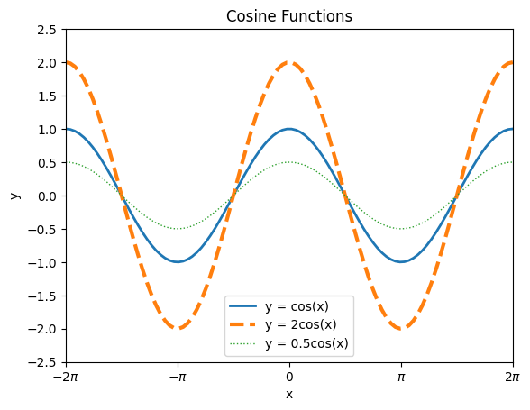

```python
import numpy as np
import matplotlib.pyplot as plt


# generate x equispaced points from -2\pi mto 2pi incluisive
x = np.linspace(-2*np.pi, 2*np.pi, 100)

# y1
y1 = np.cos(x)

# y2
y2 = 2*np.cos(x)

#y3
y3 = 1/2*np.cos(x)

# plot graphs
plt.plot(x, y1, label='y = cos(x)', linestyle='-',  linewidth=2)
plt.plot(x, y2, label='y = 2cos(x)', linestyle='--', linewidth=3)
plt.plot(x, y3, label='y = 0.5cos(x)', linestyle=':',  linewidth=1)

# limits
plt.xlim(-2*np.pi, 2*np.pi)
plt.ylim(-2.5, 2.5)

# ticks
plt.xticks(
    [-2*np.pi, -np.pi, 0, np.pi, 2*np.pi],
    [r'$-2\pi$', r'$-\pi$', '0', r'$\pi$', r'$2\pi$']
)
plt.yticks(np.arange(-2.5, 3.0, 0.5))

# labels + title
plt.xlabel('x')
plt.ylabel('y')
plt.title('Cosine Functions')

# legend
plt.legend(loc='best')

plt.show()
```

## **Question 12**:

Construct a contour plot and a 3D surface plot using the following instructions.

1. **Data**:

   x = np.linspace(-0.5, 2.0,100)

   y = np.linspace(-1.5, 4.0, 100)

   X, Y = np.meshgrid(x, y)

   $Z =f(X,Y) = (1 - X)^2 + 100 ( Y- X^2)^2$

   Note: This is a Rosenbrock function (https://en.wikipedia.org/wiki/Rosenbrock_function)
2. Create the following plots. You can make these figures in two different jupyter cells.

   **Fig1:**
   - Contour plot of Rosenbrock function
   - Provide appropriate labels and title
   - Save the figure with appropriate size and dpi

   **Fig2:**
   - Construct 3D surface of Rosenbrock function
   - Provide appropriate labels and title
   - Save the figure with appropriate size and dpi

```python
import numpy as np
import matplotlib.pyplot as plt
from mpl_toolkits.mplot3d import Axes3D

# x
x = np.linspace(-0.5, 2.0,100)

#y
y = np.linspace(-1.5, 4.0, 100)

#mesghgrid
X, Y = np.meshgrid(x,y)

# z function rosenbrock
z = (1-X)**2 + 100*(Y - X**2)**2
```

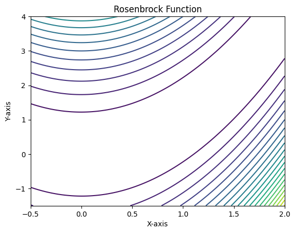

```python
#plot the contour and add labels + title
#https://matplotlib.org/stable/api/_as_gen/matplotlib.pyplot.contour.html
plt.contour(X, Y, z, levels=20)
plt.xlabel('X-axis')
plt.ylabel('Y-axis')
plt.title('Rosenbrock Function')
plt.show()

#save plot
plt.savefig("myplot.pdf", dpi = 300)
plt.show()
```

[figure not shown]

```python
#plot 3d surface and add labels + title
fig = plt.figure(figsize = (15, 15))
# using gca with projection='3d' is apparently deprecated
ax = fig.add_subplot(111,projection='3d')
surf = ax.plot_surface(X, Y, z, cmap='jet')
ax.set_xlabel('X-axis')
ax.set_ylabel('Y-axis')
ax.set_zlabel('F(x,y)')
ax.set_title('Rosenbrock Function 3D')
fig.colorbar(surf, shrink = 0.7, aspect = 5)


#save plot
plt.savefig("myplot.pdf", dpi = 300)
plt.show()
```

[output not shown]